# 11. GAM

Michał Maj

2021-05-12

# 1 Uogólnione modele addytywne - GAM

## 1.1 Regresja wielomianowa

Regresja liniowa oraz jej rozszerzenie, Uogólnione modele liniowe (GLM), zakładają że istnieje liniowa zależność między warunkową wartościa oczekiwaną (lub jej transformacja), a predyktorami:

$$\left\{\begin{array}{l}
y|X \sim O E F(\mu(\theta), \phi) \\
g(\mu)=\eta=X \beta
\end{array}\right.$$

Bardzo często okazuje się jednak, że założenie o liniowości jest niewystarczające. Do tej pory poznalismy już kilka metod rozwiązania tego problemu, a mianowicie zastosowanie nieliniowego modelu takiego jak Random forest, Boosting, Sieci Neuronowe itp. itd. Dzisiaj zastanowimy się w jaki sposób rozszerzyć modele klasy GLM do **nieliniowych zależności**.

Rozważmy na początek prosty przykład - powiedzmy, ze chcemy zamodelowac zalezność pomiędzy mocą silnika $P$, a prędkoscią maksymalną pojazdu $V$ stosując regresję liniową:

$$P|V \sim N(\mu, \sigma^2)\\
\mu = \beta_0 + \beta_1 V$$

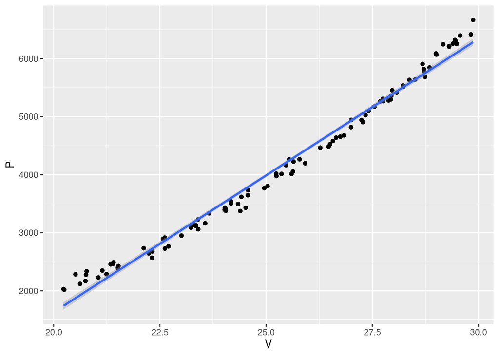

```r
power <- read_csv("power.csv")
ggplot(power, aes(V, P)) + geom_point() + geom_smooth(method = "lm", se = TRUE)
```

Dopasowanie nie jest idealne. Zaglądając do podręcznika z fizyki możemy zauważyć, że wzór relacji miedzy mocą, a predkościa wygląda następująco:

$$P = 0.5P_pC_x\rho V^3$$

Pomijając fakt, że w równaniu występują także inne zmienne (pole powierzchni czołowej pojazdu, g̨estość powietrza i bezwymiarowy współczynnik siły oporu) to warto zauważyć, że we wzorze prędkość pojawia się w potędze trzeciej. Mając to na uwadze możemy zaktualizować nasz model:

$$P|V \sim N(\mu, \sigma^2)\\
\mu = \beta_0 + \beta_1 V^3$$

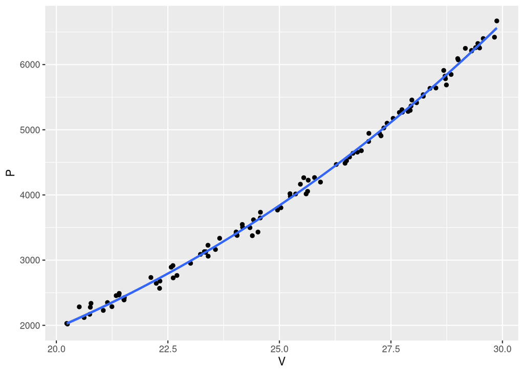

```r
ggplot(power, aes(V, P)) + geom_point() + geom_smooth(method = "glm", formula = y ~ I(x^3), se = TRUE)
```

Jak widać dopasowanie modelu jest teraz znacznie lepsze. Interpretacja modelu nie zmienia sie, poza faktem, że zalezność liniowa jest między mocą, a trzecią potęgą prędkości - podejście to nosi nazwę **regresji wielomianowej**, a jej ogólną postać mozna zapisać jako:

$$y|X \sim N(\mu, \sigma^2)\\
\mu = \beta_0 + \beta_1X + \beta_2X^2 + ... \beta_nX^n$$

Zastąpienie liniowego predyktora nieliniowym sprawia, ze jesteśmy w stanie stworzyć model lepiej dopasowany do naszych danych, jednakze nieliniowość sprawia, że trudniej jest zinterpretować nasz model. Moze takze pojawić się drugi problem - overfitting - w przypadku gdy nieliniowy predyktor jest zbyt elastyczny. dzieje się tak na przykład w przypadku regresji wielomianowej zbyt wysokiego stopnia. Zilustrujmy to na podstawie regresji stopnia 3 i 13:

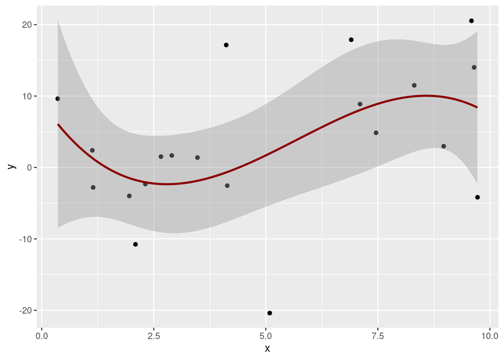

```r
data <- tibble(
  x = runif(20, 0, 10),
  y = 0.1*x^2 + rnorm(20, 0, 8)
)
ggplot(data, aes(x, y)) + geom_point() + geom_smooth(method = "glm", formula = y ~ poly(x, degree = 3), se = TRUE, color = "darkred")
```

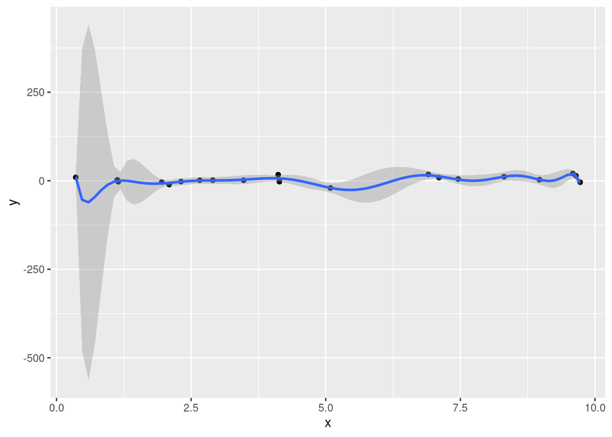

```r
ggplot(data, aes(x, y)) + geom_point() + geom_smooth(method = "glm", formula = y ~ poly(x, degree = 13), se = TRUE)
```

Regresja wielomianowa ma jeszcze jeden istotny problem. Jak widać na rysunku predykcje modelu są szczególnie niestabilbe na końcach przedziału - jest to tak zwany [Runge’s phenomenon](https://en.wikipedia.org/wiki/Runge%27s_phenomenon)

## 1.2 Model addytywny - AM

Model regresji wielomianowej jest szczególnym przypadkiem **modelu addytywnego**, którego ogólna postac wygląda następująco:

$$y|X \sim N(\mu, \sigma^2)\\
\mu = \beta_0 + f_1(X_1) + ... + f_p(X_p)$$

Model ten można traktować jako rozszerzenie klasycznego modelu regresji liniowej o nieliniowy predyktor. W modelach addytywnych najważniejszym wyzwaniem jest oczywiście odpowiedni dobór funkcji $f(.)$. Można tu wymienić 2 główne podejścia do tego problemu:

- wybór **funkcji bazowych** (basis functions)
- wybór **funkcji wygładzanych** (smoothers)

**Funkcja bazowa** jest elementem bazy pewnej **przestrzeni funkcyjnej**. oznacza to, ze każda funkcja z danej przestrzeni może być zapisana jako liniowa kombinacja funkcji bazowaych. Weźmy na przykład przestrzeń wielomianów stopnia $n$. Każdy wielomian stopnia $n$ da się zapisać jako kombinacja liniowa funkcji z bazy:

$$\{1, x, x^2, ..., x^n\}$$

Wybierając bazę wielomianową do utworzenia funkcji $f(.)$ otrzymujemy:

$$f(x) = \sum_{i=1}^n \beta_i x^i$$

co daje nam model regresji wielomianowej.

Stosowanie funkcji bazowych jest o tyle dobrym rozwiązaniem, że do estymacji możemy użyć metody najmniejszych kwadratów lub metody największej wiarygodności. wynika to z tego, że model addytywny z funkcjami bazowymi możemy przedstawić jako model z liniowym predyktorem:

$$z_1 = x, z_2 = x^2, ..., z_n = x^n \\
\eta = \beta_0 + \beta_1z_1 + ... + \beta_nz_n$$

Innymi często stosowanymi bazami są:

- radialne funkcje bazowe (radial basis functions)
- falki (wavelets)
- funkcje bazowe Fourier’a (Fourier’s basis functions)
- bazy splajnowe (spline basis)

## 1.3 Splajny

Jak zauważyliśmy przed chwilą stosowanie wielomianów zbyt wysokiego rzędu może sprawić, że krzywa regresji stanie się zbyt elastyczna, a jej wartości będą zmieniać się w zastraszającym tempie. Istnieje proste rozwiązanie tego problemu - zamiast **globalnego** dopasowanie wielomianem wysokiego rzędu możemy spróbować **lokalnie** dopasować kilka wielomianów niższego rzedu.

Oznaczmy zakres zmiennej $x$ przez $[a, b]$ i wybierzmy z niego $k$ punktów zwanych **węzłami**:

$$a< \zeta_1 < \zeta_2 < ... < \zeta_k < b$$

Na podstawie powstałych w ten sposób przedziałach dopasowywać bedziemy kolejne krzywe. Podejście to nosi nazwę **regresji kawałkami wielomianowej**. W najprostrzym przypadku mozemy uzyć wielomianów stopnia $0$ czyli po prostu indykatorów zbioru. W literaturze ten przypadek nazywany jest często **regresją funkcjami schodkowymi**:

$$z_1 = 1(x < \zeta_1), z_2 = 1(\zeta_1 \leq x < \zeta_2), ..., z_{k+1} = 1(\zeta_k \leq x)$$

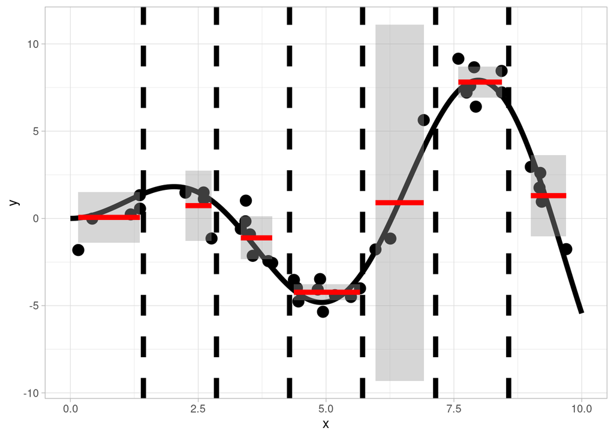

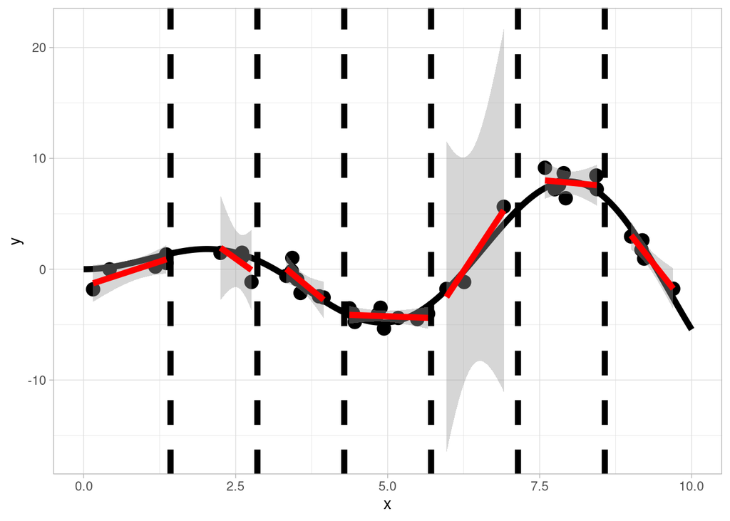

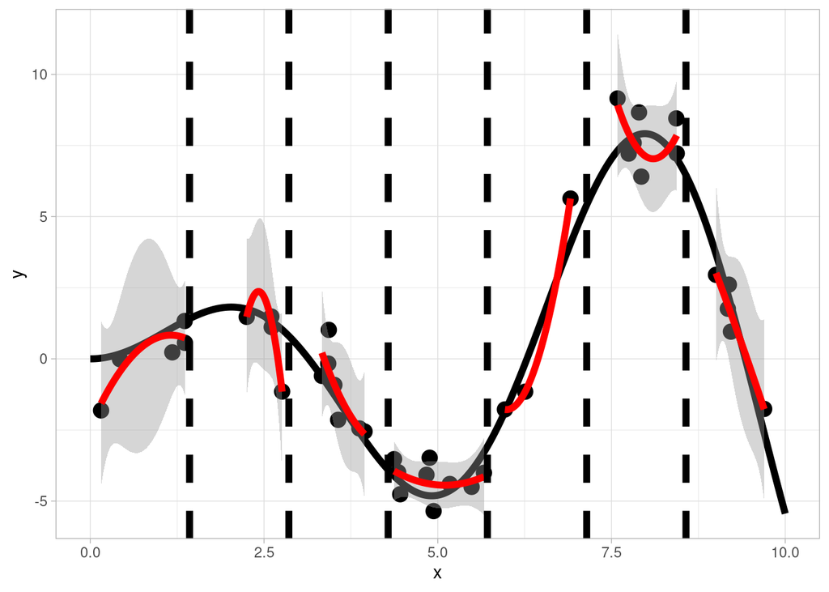

```r
wezly <- 6
wezel <- 10 / (wezly + 1) * (1:wezly)
prawda <- data.frame(a=seq(0, 10, by = 0.01), b = seq(0,10,by=0.01) * sin(seq(0, 10, by = 0.01)))
set.seed(33)
x <- runif(40, 0, 10)
gr <- c()
for(i in 1:40){
  gr<-c(gr, sum(x[i] > wezel))
}
dane <- data.frame(x = x, y = x * sin(x) + rnorm(40,0,1), gr = gr)

c(0, 1, 2) %>% walk(~ {
  if(.x == 0) {
    formu <- as.formula("y~1")
  }
  else {
    formu <- as.formula(paste0("y~poly(x, ", .x, ")"))
  }

  plot(ggplot(dane, aes(x = x,y = y,group = gr)) + geom_point(cex = 4) +
         geom_line(data = prawda, aes(group = 1, x = a,y = b), lwd = 2) +
         theme_light() + stat_smooth(method = "lm", formula = formu, col = "red", se = TRUE, lwd = 2) + geom_vline(xintercept = wezel, lty = 2,lwd = 2))
})
```

W przypadku ogólnym regresji kawałkami wielomianowej stopnia $n$ z $k$ węzłami zmienna $x$ zostaje zastąpiona przez $(n+1)(k+1) $ nowych zmiennych co daje olbrzymią liczbę parametrów do estymacji, co znowu może prowadzić do overfittingu. Nie jest to jedyny problem regresji kawałkami wielomianowej.

Na powyższym rysunku widać, ze funkcja regresji nie jest ciągła w węzłach co jest kolejną niedogodnością. Interpretacja regresji kawałkami wielomianowej jest identyczna jak poprzednio - wyestymowana krzywa interpretowana jest jako zmiana wartości oczekiwanej. Oznaczałoby to że zmiana w węzłach jest skokowa co jest dość trudne do uzasadnienia.

W prawdzie same węzły mogą być interpretowane jako miejsca, w których zmienił się charakter modelowanego zjawiska, jednak myśląc o tych zmianach zazwyczaj przychodzi nam do głowy zmiana kierunku, a nie punktowy skok.

## 1.4 Splajny

Rozwiązaniem problemu nieciagłości jest uzycie **splajnów**. Splajnem stopnia $r$ nazwiemy funkcję kawałkami wielomianową stopnia $r$, która posiada ciągłe pochodne do rzedu $r-1$ włącznie. **Bazę splajnową** możemy otrzymac poprzez dodanie do bazy wielomianowej **odciętych funkcji wielomianowych** (truncated polynomial functions) dla każdego węzła:

$$h(x, \xi)=(x-\xi)_{+}^{r}=\left\{\begin{array}{l}
(x-\xi)^{r} \operatorname{gdy} x>\xi \\
0 \text { w przeciwnym przypadku }
\end{array}\right.$$

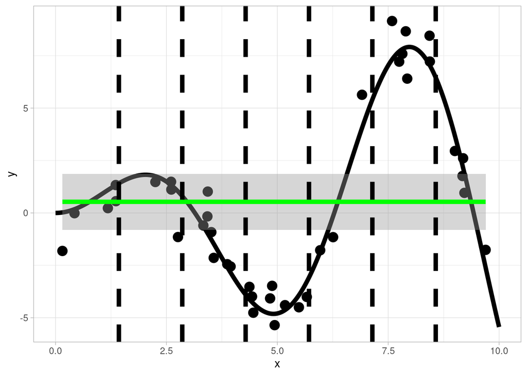

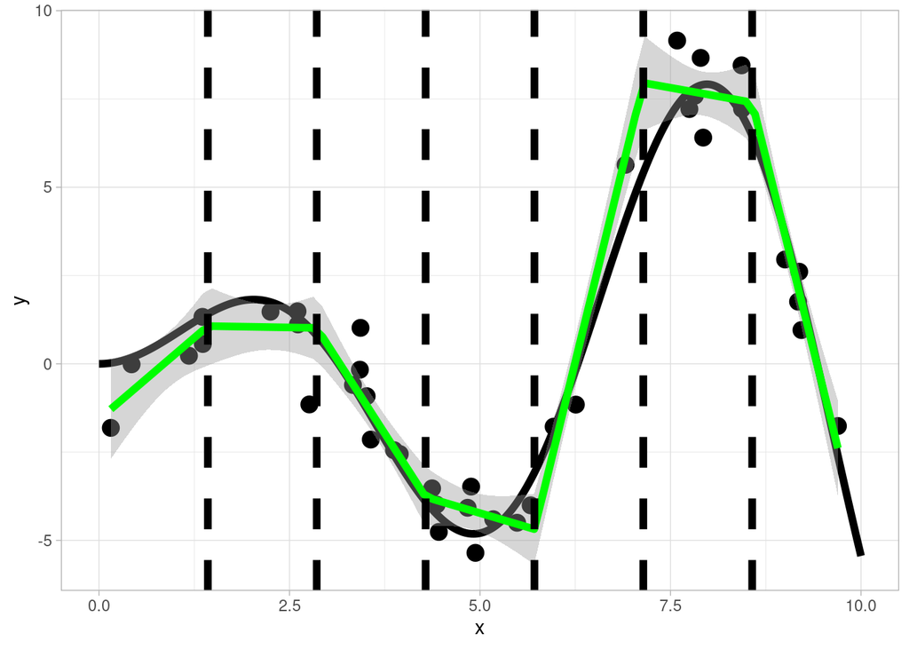

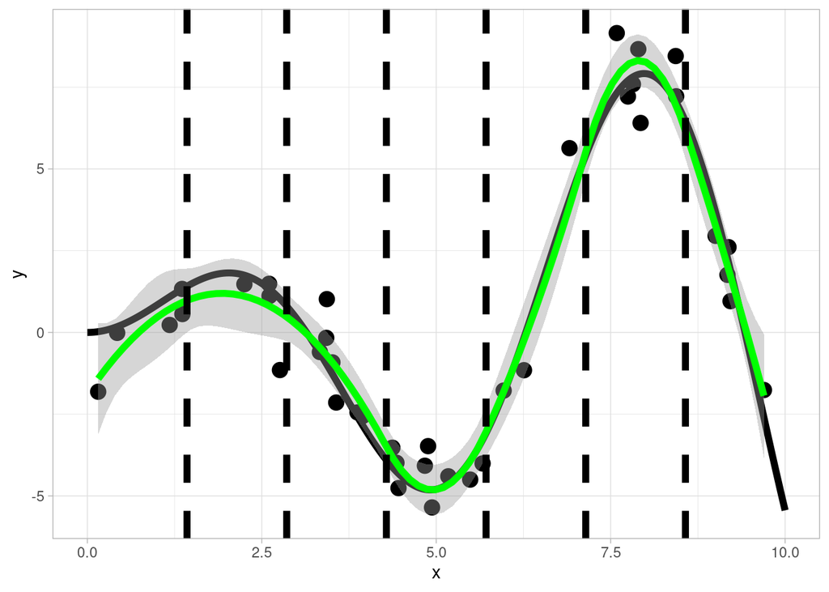

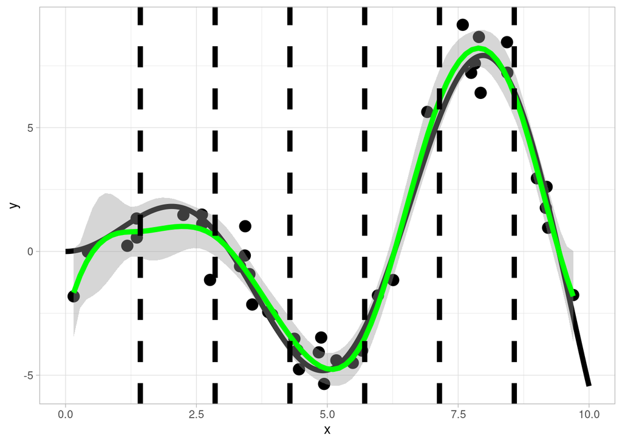

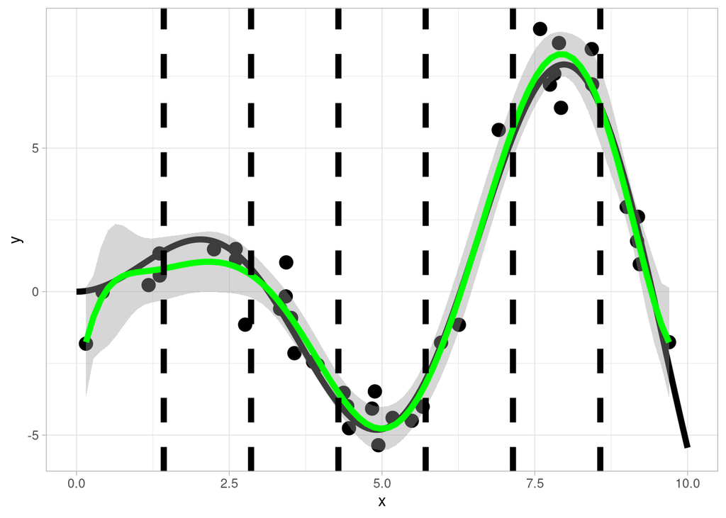

```r
wezly <- 6
wezel <- 10 / (wezly + 1) * (1:wezly)
prawda <- data.frame(a=seq(0, 10, by = 0.01), b = seq(0,10,by=0.01) * sin(seq(0, 10, by = 0.01)))
set.seed(33)
x <- runif(40, 0, 10)
gr <- c()
for(i in 1:40){
  gr<-c(gr, sum(x[i] > wezel))
}
dane <- data.frame(x = x, y = x * sin(x) + rnorm(40,0,1), gr = gr)

c(0, 1, 2, 3, 4) %>% walk(~ {
  if(.x == 0) {
    formu <- as.formula("y~1")
  }
  else {
    formu <- as.formula(paste0("y~bs(x, degree = ", .x, ", knots = wezel)"))
  }

  plot(ggplot(dane, aes(x = x,y = y)) + geom_point(cex = 4) +
         geom_line(data = prawda, aes(group = 1, x = a,y = b), lwd = 2) +
         theme_light() + stat_smooth(method = "lm", formula = formu, col = "green", se = TRUE, lwd = 2) + geom_vline(xintercept = wezel, lty = 2,lwd = 2))
})
```

Najpopularniejszą bazą splajnów jest baza **splajnów kubicznych** (cubic splines):

$$z_{1}=x, z_{2}=x^{2}, z_{3}=x^{3}, z_{4}=\left(x-\xi_{1}\right)_{+}^{3}, \ldots, z_{3+k}=\left(x-\xi_{k}\right)_{+}^{3}$$

Niestety splajny jak i wielominany posiadają bardzo dużą wariancję na brzegach przedziału predykcji. Aby rozwiązać ten problem na splajny nakłada się 2 dodatkowe ograniczenia, które nakazują splajnom **zachowywać się liniowo na brzegach**, przez co funkcja jest tam bardziej stabilna. Powstałe w ten sposób funkcje są nazywane **splajnami naturalnymi**. W przypadku naturalnych splajnów kubicznych ograniczenia te mają postać:

$$\beta_{2}=\beta_{3}=0, \sum_{i=4}^{k+4} \beta_{i}=0, \sum_{i=4}^{k+4} \xi_{i} \beta_{i}=0$$

Wyegzekwowanie takiego zachowania wymaga użycia innej bazy splajnowej - **bazy splajnów zaturalnych**:

$$\left\{N_{1}(x)=1, N_{2}(x)=x, N_{i+2}=d_{i}(x)-d_{k+1}(x)\right\}$$

gdzie $i = 1,2,...,k-2$, $k$ jest liczbą węzłów, a:

$$d_{i}(x)=\frac{\left(x-\xi_{i}\right)_{+}^{3}-\left(x-\xi_{k}\right)_{+}^{3}}{\xi_{k}-\xi_{i}}$$

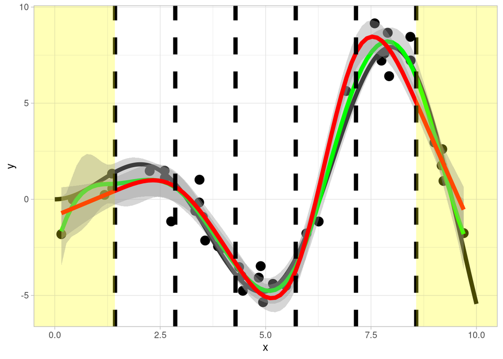

```r
wezly <- 6
wezel <- 10 / (wezly + 1) * (1:wezly)
prawda <- data.frame(a=seq(0, 10, by = 0.01), b = seq(0,10,by=0.01) * sin(seq(0, 10, by = 0.01)))
set.seed(33)
x <- runif(40, 0, 10)
gr <- c()
for(i in 1:40){
  gr<-c(gr, sum(x[i] > wezel))
}
dane <- data.frame(x = x, y = x * sin(x) + rnorm(40,0,1), gr = gr)
formu_cs <- as.formula("y~bs(x, degree = 3, knots = wezel)")
formu_ncs <- as.formula("y~ns(x,Boundary.knots=wezel[c(1,length(wezel))],knots=wezel[-c(1,length(wezel))])")

plot(ggplot(dane, aes(x = x,y = y)) + geom_point(cex = 4) +
       geom_line(data = prawda, aes(group = 1, x = a,y = b), lwd = 2) +
       theme_light() +
       stat_smooth(method = "lm", formula = formu_cs, col = "green", se = TRUE, lwd = 2) +
       stat_smooth(method = "lm", formula = formu_ncs, col = "red", se = TRUE, lwd = 2) +
       geom_vline(xintercept = wezel, lty = 2,lwd = 2) +
       geom_rect(aes(xmin = -Inf, xmax = wezel[1], ymin = -Inf, ymax = Inf), alpha = 0.008, fill = "yellow") +
       geom_rect(aes(xmin = wezel[length(wezel)], xmax = Inf, ymin = -Inf, ymax = Inf), alpha = 0.008, fill = "yellow"))
```

## 1.5 Splajny wygładzone

Wykorzystując regresję wielomianową, splajnową lub jakikolwiek inny model addytywny mamy na celu jedną rzecz. Chcemy znaleźć **funkcję gładką**, która w rzetelny sposób będzie odwzorowywać zmianę warunkowej wartości oczekiwanejmodelowanej zmiennej. W poprzednich podrozdziałach pokazałem jak mozna zrobić to stosując funkcje bazowe. Przy wykorzystaniu funkcji bazwych mozliwa była próba interpretacji modelu - poprzez interpretację nowych zmiennych. Prawda jest jednak taka, że w wiekszości przypadków relacja między zmienną objaśniana, a predyktorami jest złozona i niemożliwa do odgadnięcia.

Weźmy na przykład interpretację punktów węzłowych. Jak wspomniałem możemy je interpretować jako miejsca, w których krzywa regresji zmienia się (strukturalnie). Jednakże czy w rzeczywistości jesteśmy w stanie odnaleźć te punkty (uzaadnić ich wybór)? Częstą metodą wyboru węzłów jest ustawienie ich w sposób równomierny (np. jako kwantyle) lub ustawienie większej ilości węzłów tam gdzie mamy do czynienia z większym skupiskiem danych.

Zapomnimy teraz o interpretowalności naszego modelu (zmiennych) i skupimy się wyłacznie na znalezieniu funkcji gładkiej $g(.)$, która bedzie dobrze dopasowana do naszych danych - czyli minimalizować wyrażenia:

$$R S S=\sum_{i=1}^{n}\left(y_{i}-g\left(x_{i}\right)\right)^{2}$$
Jest to oczywiście błąd kwadratowy, z tą róœnicą, że $g(.)$ jest teraz dowolną funkcja, a nie funkcją liniową predyktorów. Dowolność w strukturze funkcji $g(.)$ skutkować będzie idealnym dopasowaniem do zbioru treningowego - overfittingiem. Aby rozwiązać ten problem musimy dodać penalizację do naszego modelu, tak aby $g(.)$ nie była zbyt elastyczna, ale pozostała gładka:

$$P R S S=\sum_{i=1}^{n}\left(y_{i}-g\left(x_{i}\right)\right)^{2}+\lambda \int_{a}^{b} g^{\prime \prime}(t)^{2} d t$$

Interpretacja wzoru jest następująca. Suma po lewej to jak poprzednio błąd kwadratowy mierzący dopasowanie. Całka po prawej mierzy krzywiznę funkcji i nazywana jest **karą za niegładkość**. Wartość $\lambda$ to **współczynnik kary**. Funkcja, która minimalizuje powyższe wyażenie nazywana jest **splajnem wygładzonym** (smoothing spline).

Jak sama nazwa mówi splajn wygładzony jest splajnem, a dokładniem naturalnym splajnem kubicznym, co za chwilę wykażemy.

Zacznimy od zestawu punktów $(x_i, y_i)$, gdzie $n>1$ i $a<x_1<...<x_n<b$. oznaczmy przez

$$\tilde{g}(x)$$
dowolną podwójnie różniczkowalną funkcję, a jej predykcje dla wartości $y_i$ poprzez:

$$\tilde{g}\left(x_{i}\right)$$

Rozpatrzmy naturalny splajn kubiczny, którego węzłami będą wszystkie punkty $x_i$. Ponieważ kazdy punkt stanowi węzeł to zawsze jesteśmy w stanie dobrać takie wartości $\beta_i$, że funkcja:

$$g(x)=\sum_{i=1}^{n} \beta_{i} N_{i}(x)$$

może interpolować wartości:

$$g\left(x_{i}\right)=\tilde{g}\left(x_{i}\right)$$

$N_{i}(x)$ są bazą naturalych splajnów kubicznych. Jak łatwo zauważych, pierwsza część wyrażenia jest identyczna dla obu funkcji:

$$\sum_{i=1}^{n}\left(y_{i}-g\left(x_{i}\right)\right)^{2}=\sum_{i=1}^{n}\left(y_{i}-\tilde{g}\left(x_{i}\right)\right)^{2}$$

Co oznacza, że minimalizacja całego wyrażenia zalezy tylko i wyłącznie od krzywizny funkcji. Oznaczmy:

$$h(x)=g(x)-\tilde{g}(x)$$

i rozpatrzmy całkę:

$$\begin{array}{c}
\left.\int_{a}^{b} g^{\prime \prime}(t) h^{\prime \prime}(t) d t \stackrel{*}{=} g^{\prime \prime}(t) h^{\prime \prime}(t)\right|_{a} ^{b}-\int_{a}^{b} g^{\prime \prime \prime}(t) h(t) d t \stackrel{* *}{=} \\
\stackrel{* *}{=}-\sum_{j=1}^{n-1} g^{\prime \prime \prime}\left(x_{j}^{+}\right) \int_{x_{j}}^{x_{j+1}} h^{\prime}(t) d t=-\sum_{j=1}^{n-1} g^{\prime \prime \prime}\left(x_{j}^{+}\right)\left(h\left(x_{j+1}\right)-h\left(x_{j}\right)\right)=0
\end{array}$$

gdzie w (*) skorzystaliśmy z całkowania przez części, a w (**) z tego, że $g''(a)=g''(b)=0$. Z powyższego łatwo pokazać, że:

$$\int_{a}^{b} \tilde{g}^{\prime \prime 2}=\int_{a}^{b}\left(g^{\prime \prime}+h^{\prime \prime}\right)^{2}=\int_{a}^{b} g^{\prime \prime 2}+2 \int_{a}^{b} g^{\prime \prime} h^{\prime \prime}+\int_{a}^{b} h^{\prime \prime 2}=\int_{a}^{b} g^{\prime \prime 2}+\int_{a}^{b} h^{\prime 2} \geqslant \int_{a}^{b} g^{\prime \prime 2}$$

Wynika stad, że funkcją minimalizującą jest naturalny splan kubiczny z węzłami w każdym punkcie $x_i$, a raczej jego **zwężona wersja**, w której parametr $\lambda$ kontroluje stopień zwężenia. Ponieważ wiemy, ze szukaną przez nas funkcją jest naturalny splajn kubiczny to nasze kryterium możemy zapisać jako:

$$P R S S=(y-N \hat{\beta})^{T}(y-N \hat{\beta})+\lambda \hat{\beta}^{T} \Omega_{N} \hat{\beta}$$

gdzie:

$$\left\{\Omega_{N}\right\}_{i j}=\int N_{j}^{\prime \prime}(t) N_{k}^{\prime \prime}(t) d t$$

Rozwiązaniem powyzszego kryterium jest:

$$\hat{\beta}=\left(N^{T} N+\Omega_{N}\right)^{-1} N^{T} y$$

Mając wzór na $\hat{\beta}$ możemy zapisać wzór na wartości dopasowane:

$$\hat{y}=N \hat{\beta}=N\left(N^{T} N+\Omega_{N}\right)^{-1} N^{T} y=S_{\lambda} y$$

Przypomina to bardzo wynik dla regresji liniowej $\hat{y}=P_Xy$, gdzie $P_X$ było rzutem (operatorem liniowym). W przypadku splajnów wygładzonych otrzymujemy analogiczny operator liniowy nazywany **macierzą wygładzania**. Wielkość penalizacji w przypadku splajnów wygładzonych określa się przez **efektywne stopnie swobody**:

$$d f_{\lambda}=\operatorname{trace}\left(S_{\lambda}\right)$$

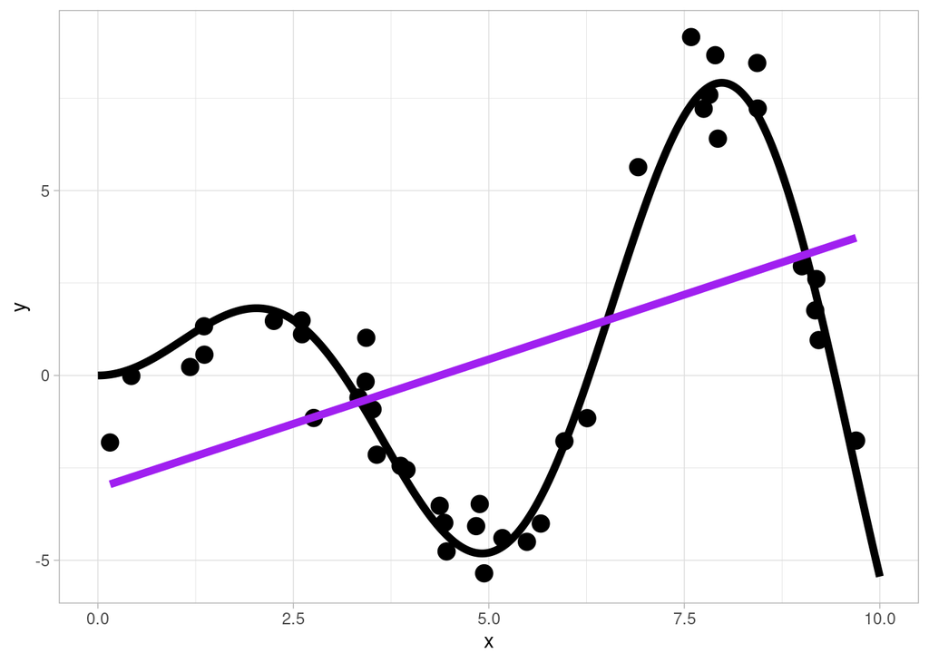

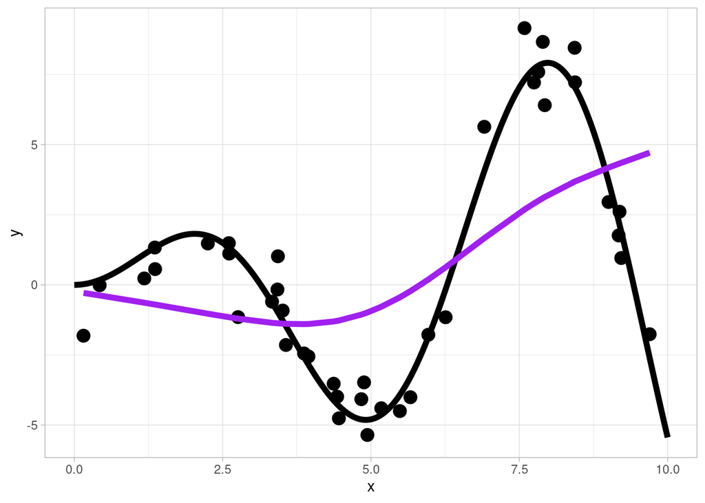

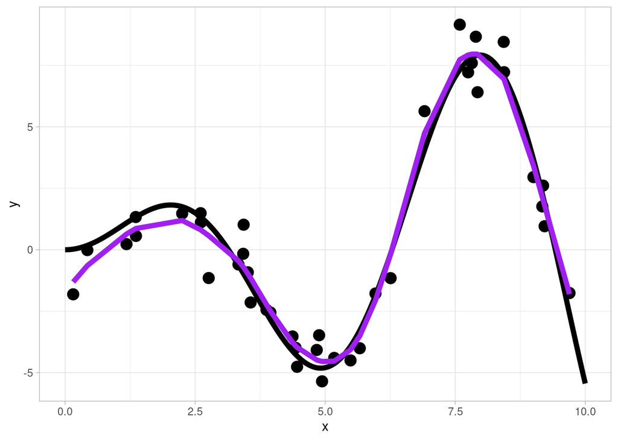

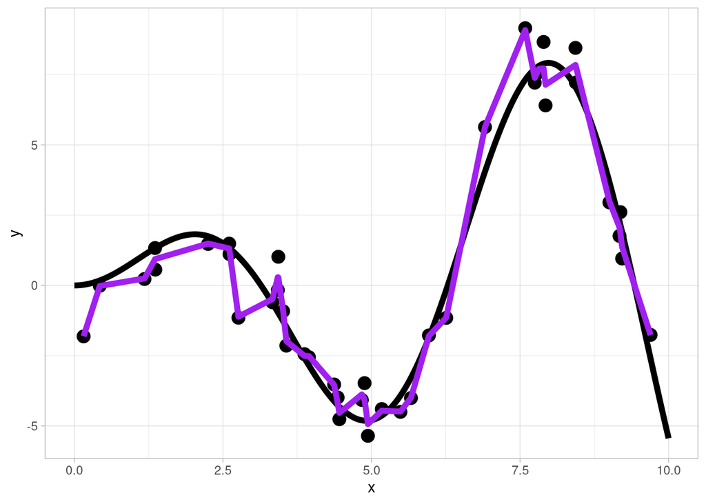

```r
wezly <- 6
wezel <- 10 / (wezly + 1) * (1:wezly)
prawda <- data.frame(a=seq(0, 10, by = 0.01), b = seq(0,10,by=0.01) * sin(seq(0, 10, by = 0.01)))
set.seed(33)
x <- runif(40, 0, 10)
gr <- c()
for(i in 1:40){
  gr<-c(gr, sum(x[i] > wezel))
}
dane <- data.frame(x = x, y = x * sin(x) + rnorm(40,0,1), gr = gr)

c(1.5, 3, 10, 30) %>% walk(~ {
  dane1 <- data.frame(x = x,y = predict(smooth.spline(x, y = dane$y, df = .x),x)$y)

plot(ggplot(dane, aes(x = x,y = y)) + geom_point(cex = 4) +
       geom_line(data = prawda, aes(group = 1, x = a,y = b), lwd = 2) +
       theme_light() +
       geom_line(data = dane1, aes(x = x, y = y, group = 1), col = "purple" ,lwd = 2))
})
```

## 1.6 LOESS/LOWESS

Kolejną nieparametryczna alternatywą dla splanów wygładzonych jest **regresja lokalna LOESS/LOWESS** (locally weighted scatterplot smoothing). Metoda ta jest pewnego rodzaju połączeniem **ważonej metody najmniejszych kwadratów** oraz **K-najbliższych sąsiadów**. Działa ona następująco:

1. Dla punktu $x_0$ bierzemy pewne sąsiedztwo $O(x_0)$
2. Dla kazdego punktu z sąsiedztwa ustalamy ewną wagę $K_{i0}=K(x_0, x_i)$, tak aby najdalej oddalony punkt od $x_o$ miał wagę równą $0$, a najbliższy najwyzszą. Wagi dla punktów liczone zazwyczaj są przy pomocy **kerneli**
3. Dla punktów z sąsiedztwa tworzymy model ważoną MNK. I liczymy predykcje dla $x_0$
4. Powtarzamy dla kolejnych punktów

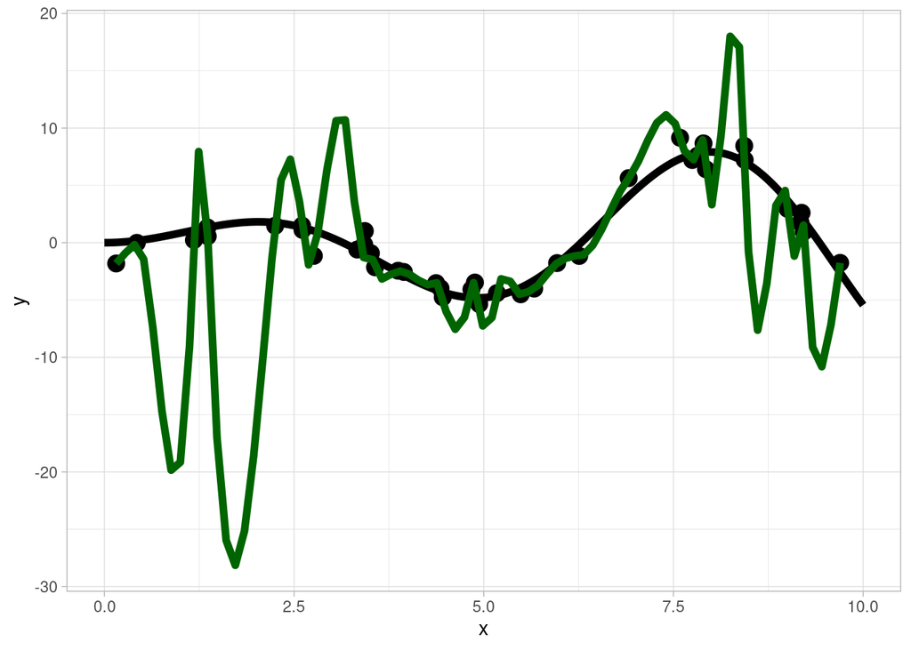

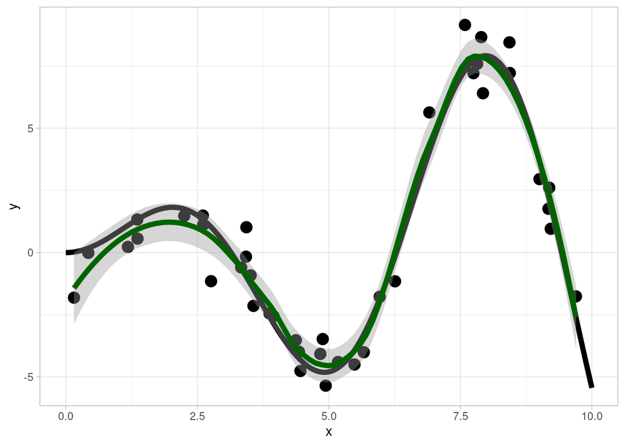

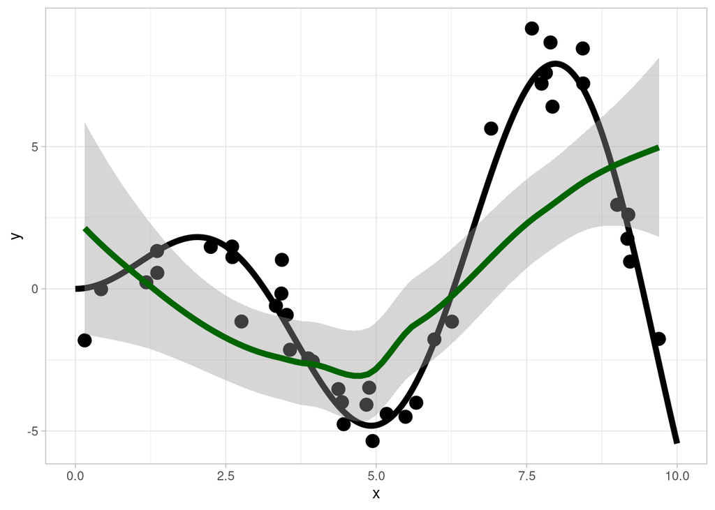

```r
wezly <- 6
wezel <- 10 / (wezly + 1) * (1:wezly)
prawda <- data.frame(a=seq(0, 10, by = 0.01), b = seq(0,10,by=0.01) * sin(seq(0, 10, by = 0.01)))
set.seed(33)
x <- runif(40, 0, 10)
gr <- c()
for(i in 1:40){
  gr<-c(gr, sum(x[i] > wezel))
}
dane <- data.frame(x = x, y = x * sin(x) + rnorm(40,0,1), gr = gr)

c(0.1, 0.5, 1) %>% walk(~ {
  dane1 <- data.frame(x = x,y = predict(smooth.spline(x, y = dane$y, df = .x),x)$y)

plot(ggplot(dane, aes(x = x,y = y)) + geom_point(cex = 4) +
       geom_line(data = prawda, aes(group = 1, x = a,y = b), lwd = 2) +
       theme_light() +
       stat_smooth(col = "darkgreen", se = TRUE, lwd = 2, span = .x))
})
```

## 1.7 Uogólnione modele addytywne - GAM

Model addytywny jest naturalnym rozszerzeniem regresji liniowej o nieliniowy predyktor. analogiczne rozszerzenie muszą mieć GLM. **Uogólnionym modelem addytywnym** (GAM) nazwiemy model postaci:

$$\left\{\begin{array}{l}
y \sim N E F(\mu(\theta), \phi) \\
g(\mu)=\eta^{*}=\beta_{0}+f_{1}\left(X_{1}\right)+\ldots+f_{n}\left(X_{n}\right)
\end{array}\right.$$

Estymacja modelu podobnie jak w przypadku GLM może być wykonana przy pomocy metody największej wiarygodności. Jesli za funkcje $f_i(.)$ przyjmiemy funkcje tworzone na podstawie funkcji bazowych to nie ma tu różnicy, jednakże jeśli będziemy chcieli wykorzystać splajny wygładzane lub LOWESS to minimalizować będziemy **penalizowane log-likelihood**:

$$\ell_{p}\left(\eta^{*} \mid y\right)=\ell\left(\eta^{*} \mid y\right)-\frac{1}{2} \sum_{j=1}^{p} \lambda_{j} \int f_{j}^{\prime \prime}(t)^{2} d t$$

Minimalizacja penalizowanego log-likelihood przebiega przy użyciu **algorytmu lokalnego scoringu** (ważonym algorytmie wielokrotnego dopasowania) w którym to aktualizujemy dopasowanie kazdego z predyktorów z osobna traktując pozostałe predyktory jako stałe.

ALGORYTM WIELOKROTNEGO DOPASOWANIA DLA MODELU ADDYTYWNEGO:

1. Inicjalizacja wartości początkowych:

$$\hat{\beta}_{0}=\bar{y}, \hat{f}_{j}^{(0)}\left(X_{j}\right)=0, j=1,2, \ldots, p$$

2. Dla $j=1,2, \ldots, p$ powtarzamy cykle:

$$\begin{array}{c}
\hat{\eta}_{i}^{(k)}=\hat{\beta}_{0}+\sum_{j=1}^{p} \hat{f}_{j}^{(k)}(i j) \\
\hat{\mu}_{i}^{(k)}=g^{-1}\left(\hat{\eta}_{i}^{(k)}\right) \\
z_{i}=\hat{\eta}_{i}^{(k)}+\left(y_{i}-\hat{\mu}_{i}^{(k)}\right) g^{\prime}\left(\hat{\mu}_{i}^{(k)}\right) \\
w_{i}=\frac{1}{\operatorname{Var}\left(y_{i}\right)^{(k)} g^{\prime 2}\left(\hat{\mu}_{i}^{(k)}\right)}
\end{array}$$
a nastepnie użycie ważonego algorytmu wielokrotnego dopasowania z wagami $w_i$ dla zmiennych $z_i$

$$\begin{array}{c}
R^{(j)}=y-\hat{\beta}_{0}-\sum_{i=1}^{j-1} \hat{f}_{i}^{(k+1)}\left(X_{i}\right)-\sum_{i=j+1}^{p} \hat{f}_{i}^{(k)}\left(X_{i}\right) \\
\hat{f}_{j}^{(k+1)}\left(X_{j}\right)=S_{j}\left(R^{(j)}\right)
\end{array}$$

gdzie zapis $S_{j}\left(R^{(j)}\right)$ oznacza estymację przy użyciu pewnej metody wygładzanej (splajny wygładzane, regresja lokalna, funkcje jądrowe).

3. Przerywamy algorytm w momencie gdy aktualizacje $\hat{f}_{j}^{(k+1)}\left(X_{j}\right)$ nie będą się zmieniać o więcej niż zadany próg $\epsilon$